# CSCI E-63C: Week 2 Q&A session

# Questions

- Week 1 homework
- Week 1 lecture
- Upcoming homework
- Upcoming quiz

# Simple ggplot example

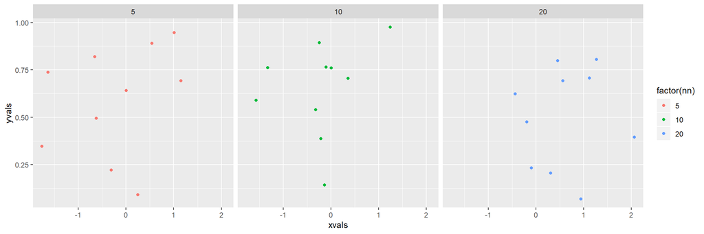

```r
dfTmp <- data.frame(xvals=rnorm(30),yvals=runif(30),nn=rep(c(5,10,20),10))
ggplot(dfTmp,aes(x=xvals,y=yvals,colour=factor(nn)))+geom_point()+facet_wrap(~nn)
```

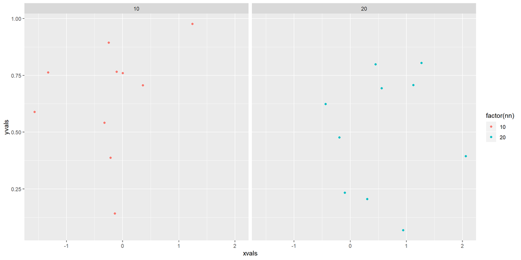

```r
ggplot(dfTmp[dfTmp$nn!=5,],aes(x=xvals,y=yvals,colour=factor(nn)))+geom_point()+facet_wrap(~nn)
```

# Factors and type conversion example

```r
x <- 1:5; someLetters <- letters[seq_along(x)]; someLetters
```

```
## [1] "a" "b" "c" "d" "e"
```

```r
names(x) <- someLetters; x
```

```
## a b c d e
## 1 2 3 4 5
```

```r
names(x) <- sample(names(x)); x
```

```
## a c e d b
## 1 2 3 4 5
```

```r
x[someLetters]
```

```
## a b c d e
## 1 5 2 4 3
```

```r
fSomeLetters <- factor(someLetters); fSomeLetters
```

```
## [1] a b c d e
## Levels: a b c d e
```

```r
as.character(fSomeLetters); x[as.character(fSomeLetters)]
```

```
## [1] "a" "b" "c" "d" "e"
```

```
## a b c d e
## 1 5 2 4 3
```

```r
x[fSomeLetters]
```

```
## a c e d b
## 1 2 3 4 5
```

# Some of the R conveniences

- `ggplot2` – popular plotting package providing unified interface to variety of visualizations (e.g. don’t have to remember how to combine `boxplot` and `stripchart`)
- tidy data: `reshape2`, `plyr`, … – very convenient together with `ggplot`, standardizes many common data transformations
- OOP: class is just an attribute that is easy to change, s3/s4/rc frameworks, dots in names, http://adv-r.had.co.nz/OO-essentials.html
- `shiny` – enabling interactive R over web

# S3 OOP in R: a word of caution

```r
fSomeLetters
```

```
## [1] a b c d e
## Levels: a b c d e
```

```r
class(fSomeLetters)
```

```
## [1] "factor"
```

```r
is.object(fSomeLetters) & !isS4(fSomeLetters)
```

```
## [1] TRUE
```

```r
class(fSomeLetters) <- "Let's get wild here"; class(fSomeLetters)
```

```
## [1] "Let's get wild here"
```

```r
fSomeLetters
```

```
## [1] 1 2 3 4 5
## attr(,"levels")
## [1] "a" "b" "c" "d" "e"
## attr(,"class")
## [1] "Let's get wild here"
```

```r
class(fSomeLetters) <- c("One class","another class"); fSomeLetters
```

```
## [1] 1 2 3 4 5
## attr(,"levels")
## [1] "a" "b" "c" "d" "e"
## attr(,"class")
## [1] "One class"     "another class"
```

```r
# attribute "class" determines which "print" is called:
class(fSomeLetters) <- "factor"; fSomeLetters
```

```
## [1] a b c d e
## Levels: a b c d e
```

# ISLR Ch.2.3.4 (Lab)

```r
##?Auto
class(Auto)
```

```
## [1] "data.frame"
```

```r
dim(Auto)
```

```
## [1] 392   9
```

```r
summary(Auto)
```

```
##       mpg          cylinders      displacement     horsepower
##  Min.   : 9.00   Min.   :3.000   Min.   : 68.0   Min.   : 46.0
##  1st Qu.:17.00   1st Qu.:4.000   1st Qu.:105.0   1st Qu.: 75.0
##  Median :22.75   Median :4.000   Median :151.0   Median : 93.5
##  Mean   :23.45   Mean   :5.472   Mean   :194.4   Mean   :104.5
##  3rd Qu.:29.00   3rd Qu.:8.000   3rd Qu.:275.8   3rd Qu.:126.0
##  Max.   :46.60   Max.   :8.000   Max.   :455.0   Max.   :230.0
##
##      weight      acceleration        year           origin
##  Min.   :1613   Min.   : 8.00   Min.   :70.00   Min.   :1.000
##  1st Qu.:2225   1st Qu.:13.78   1st Qu.:73.00   1st Qu.:1.000
##  Median :2804   Median :15.50   Median :76.00   Median :1.000
##  Mean   :2978   Mean   :15.54   Mean   :75.98   Mean   :1.577
##  3rd Qu.:3615   3rd Qu.:17.02   3rd Qu.:79.00   3rd Qu.:2.000
##  Max.   :5140   Max.   :24.80   Max.   :82.00   Max.   :3.000
##
##                  name
##  amc matador       :  5
##  ford pinto        :  5
##  toyota corolla    :  5
##  amc gremlin       :  4
##  amc hornet        :  4
##  chevrolet chevette:  4
##  (Other)           :365
```

```r
head(Auto)
```

```
##   mpg cylinders displacement horsepower weight acceleration year origin
## 1  18         8          307        130   3504         12.0   70      1
## 2  15         8          350        165   3693         11.5   70      1
## 3  18         8          318        150   3436         11.0   70      1
## 4  16         8          304        150   3433         12.0   70      1
## 5  17         8          302        140   3449         10.5   70      1
## 6  15         8          429        198   4341         10.0   70      1
##                        name
## 1 chevrolet chevelle malibu
## 2         buick skylark 320
## 3        plymouth satellite
## 4             amc rebel sst
## 5               ford torino
## 6          ford galaxie 500
```

```r
names(Auto)
```

```
## [1] "mpg"          "cylinders"    "displacement" "horsepower"
## [5] "weight"       "acceleration" "year"         "origin"
## [9] "name"
```

```r
colnames(Auto)
```

```
## [1] "mpg"          "cylinders"    "displacement" "horsepower"
## [5] "weight"       "acceleration" "year"         "origin"
## [9] "name"
```

```r
# ISLR says there are 397 rows, five of which include ?'s:
for ( tmpCnm in colnames(Auto) ) {
  cat(tmpCnm,class(Auto[,tmpCnm]),sum(Auto[,tmpCnm]=="?"),fill=TRUE)
}
```

```
## mpg numeric 0
## cylinders numeric 0
## displacement numeric 0
## horsepower numeric 0
## weight numeric 0
## acceleration numeric 0
## year numeric 0
## origin numeric 0
## name factor 0
```

```r
#?write.table
#?read.table
write.table(Auto,"Auto.txt")
autoDat <- read.table("Auto.txt")
head(autoDat)
```

```
##   mpg cylinders displacement horsepower weight acceleration year origin
## 1  18         8          307        130   3504         12.0   70      1
## 2  15         8          350        165   3693         11.5   70      1
## 3  18         8          318        150   3436         11.0   70      1
## 4  16         8          304        150   3433         12.0   70      1
## 5  17         8          302        140   3449         10.5   70      1
## 6  15         8          429        198   4341         10.0   70      1
##                        name
## 1 chevrolet chevelle malibu
## 2         buick skylark 320
## 3        plymouth satellite
## 4             amc rebel sst
## 5               ford torino
## 6          ford galaxie 500
```

```r
dim(autoDat)
```

```
## [1] 392   9
```

```r
dim(na.omit(autoDat))
```

```
## [1] 392   9
```

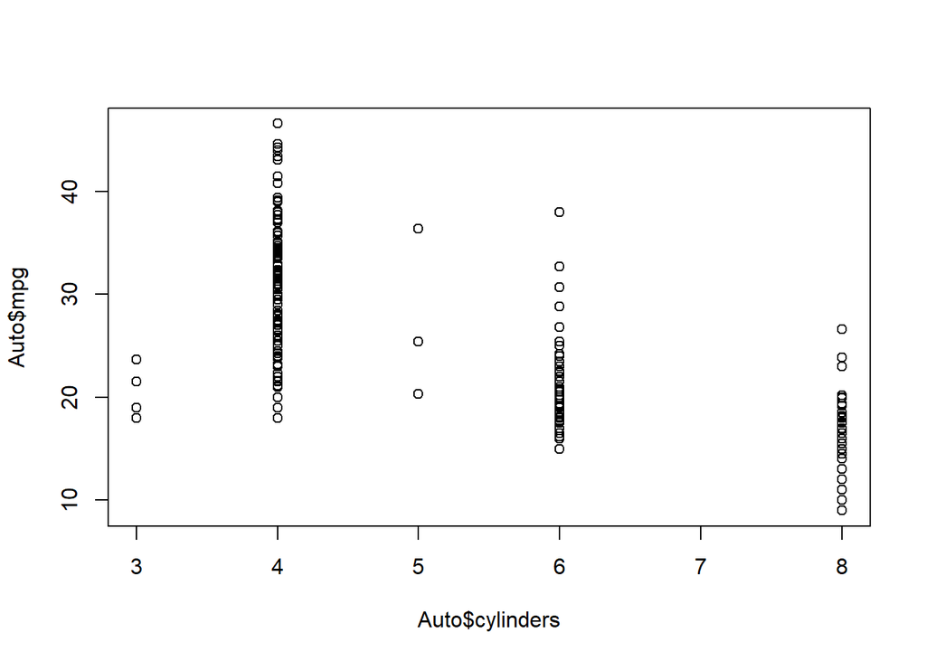

```r
if ( FALSE ) {
  plot(cylinders, mpg)
}
plot(Auto$cylinders, Auto$mpg)
```

```r
attach (Auto)
```

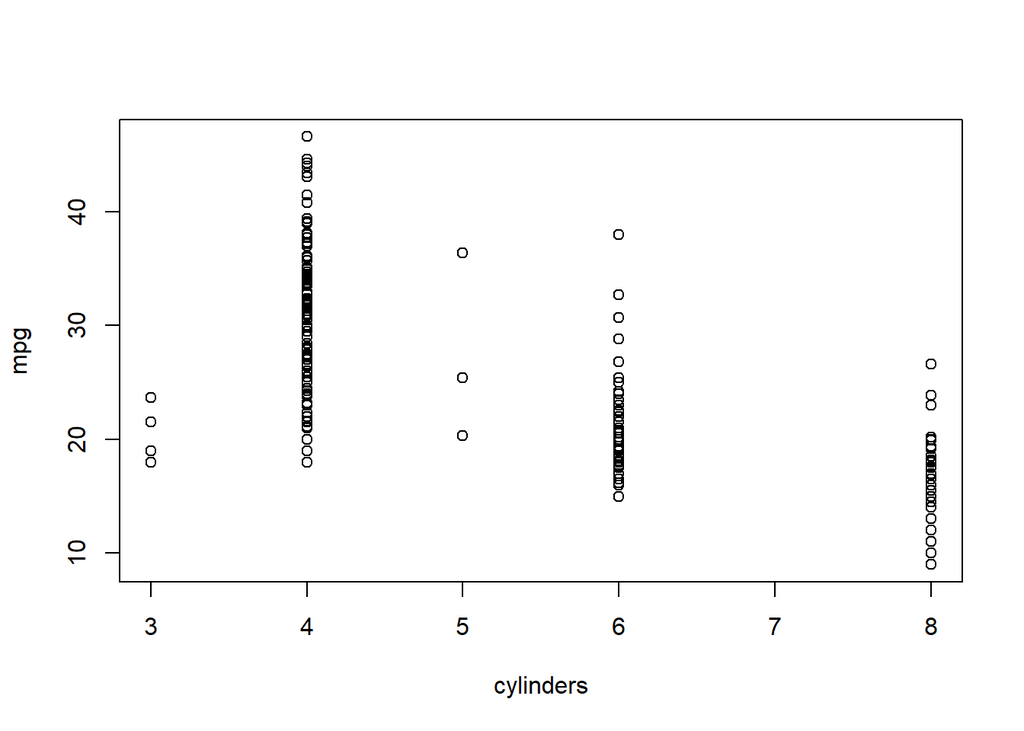

```r
plot(cylinders, mpg)
```

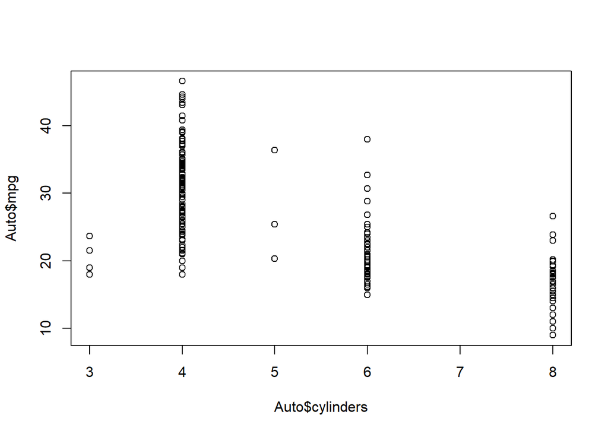

```r
detach (Auto)
plot(Auto$cylinders, Auto$mpg)
```

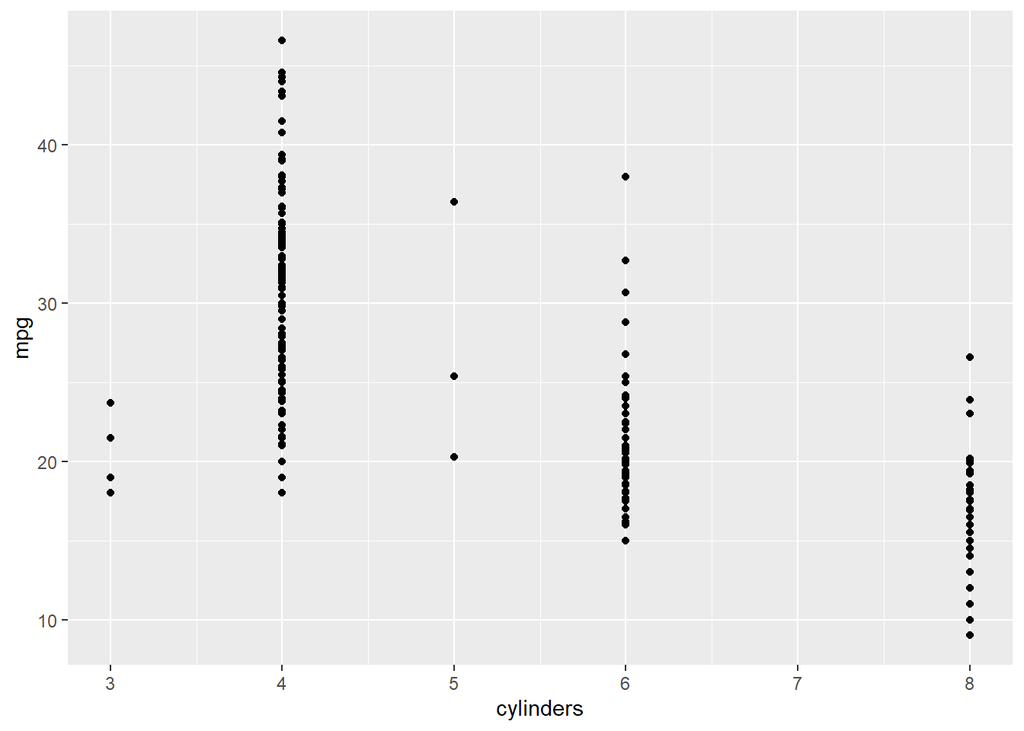

```r
ggplot(Auto,aes(x=cylinders,y=mpg))+geom_point()
```

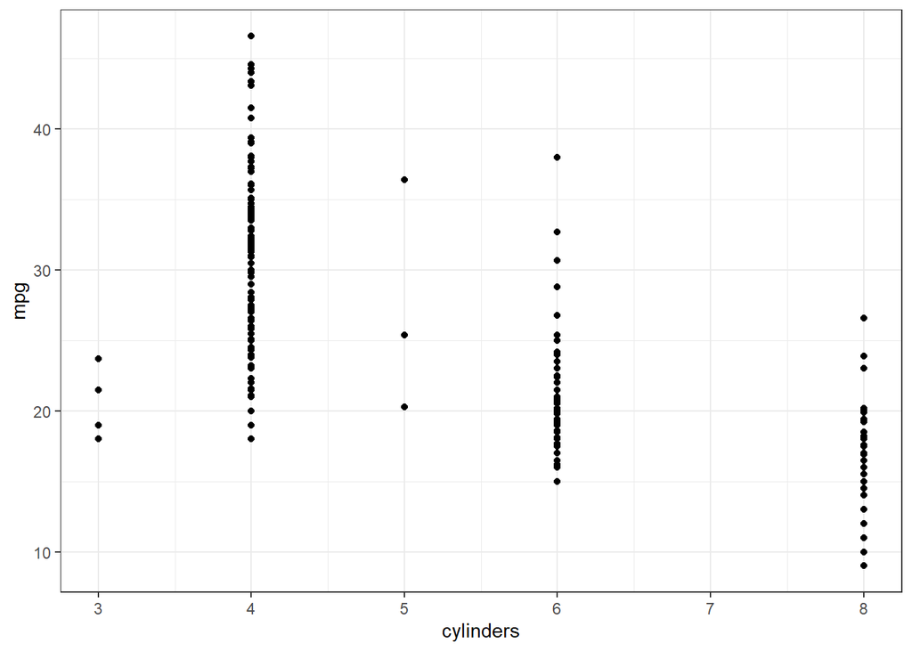

```r
ggplot(Auto,aes(x=cylinders,y=mpg))+geom_point()+theme_bw()
```

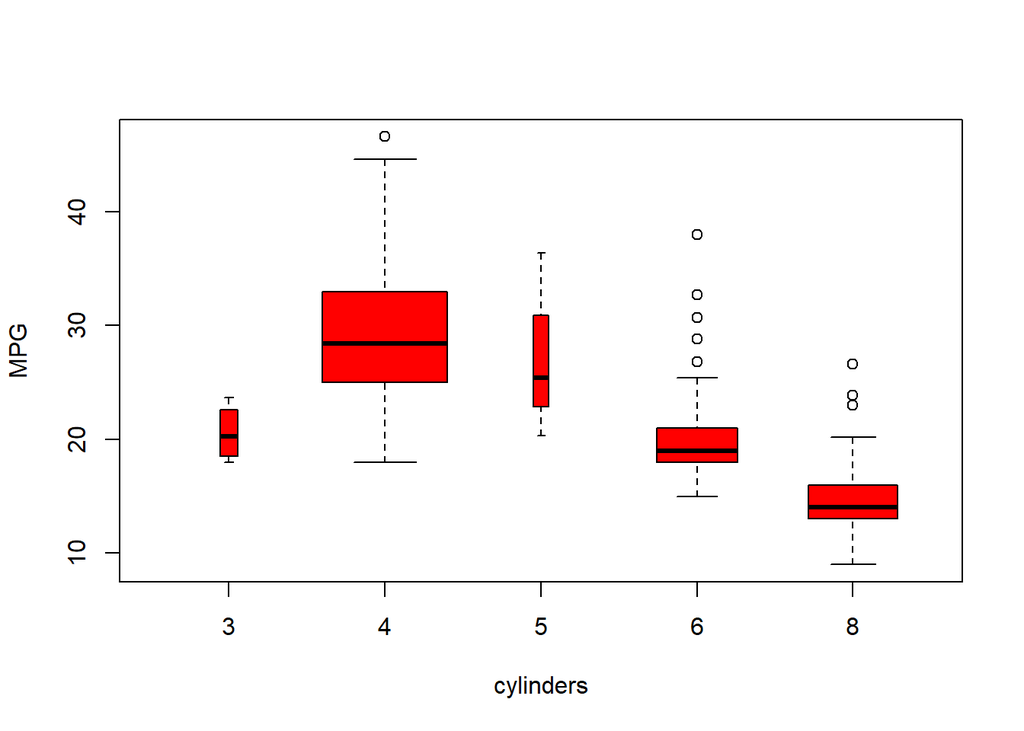

```r
plot(factor(Auto$cylinders), Auto$mpg, col ="red", varwidth=T, xlab="cylinders", ylab="MPG")
```

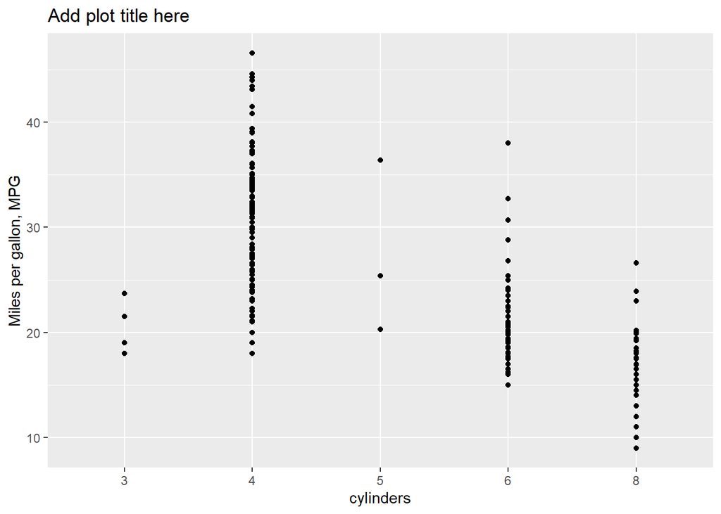

```r
ggplot(Auto,aes(x=factor(cylinders),y=mpg))+geom_point()+ggtitle("Add plot title here")+xlab("cylinders")+ylab("Miles per gallon, MPG")
```

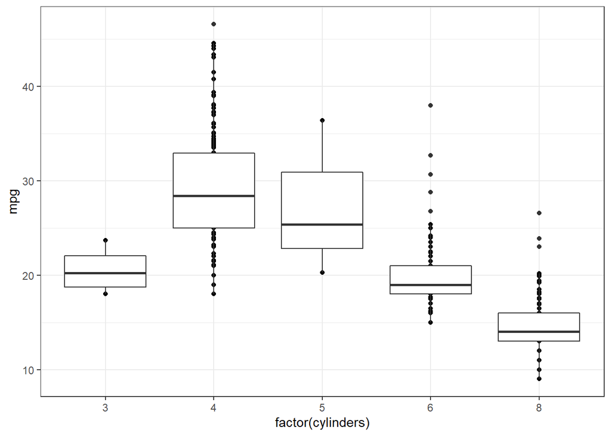

```r
ggplot(Auto,aes(x=factor(cylinders),y=mpg))+geom_point()+geom_boxplot()+theme_bw()
```

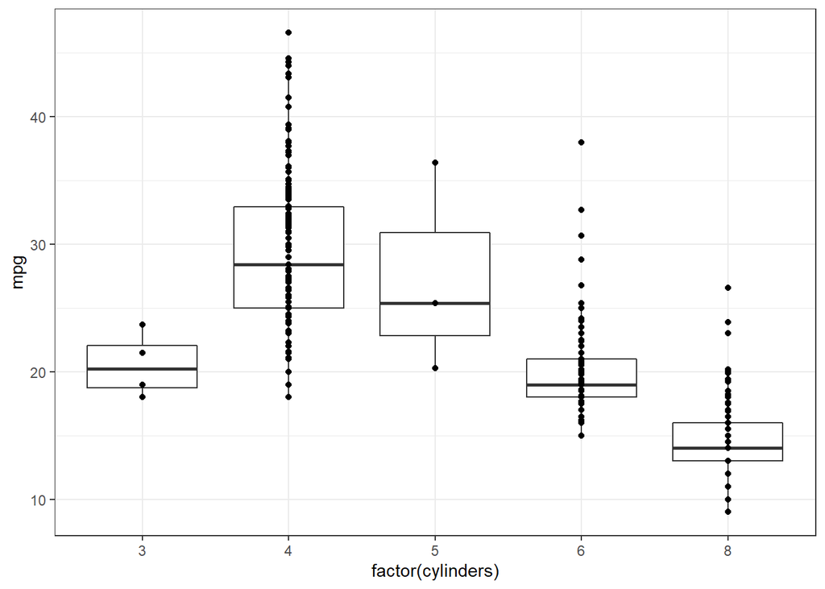

```r
ggplot(Auto,aes(x=factor(cylinders),y=mpg))+geom_boxplot()+geom_point()+theme_bw()
```

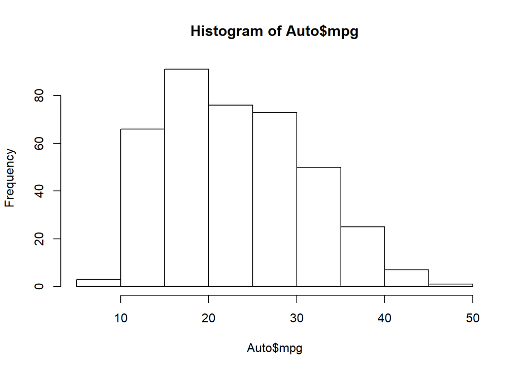

```r
hist(Auto$mpg)
```

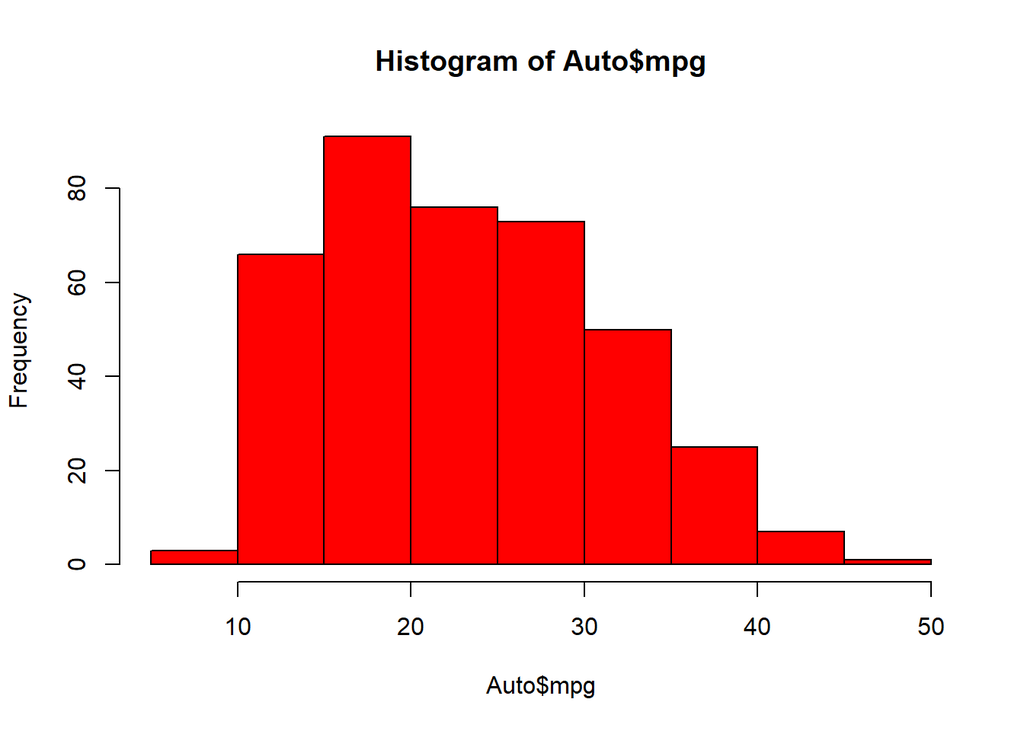

```r
hist(Auto$mpg,col="red")
```

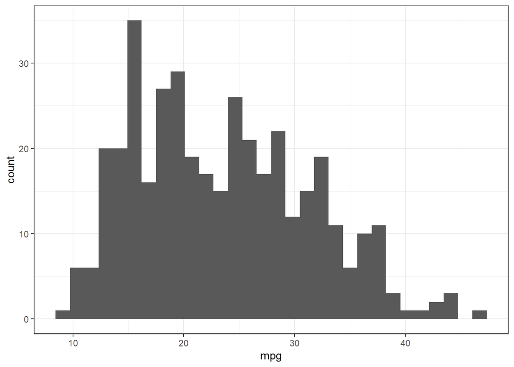

```r
ggplot(Auto,aes(x=mpg))+geom_histogram()+theme_bw()
```

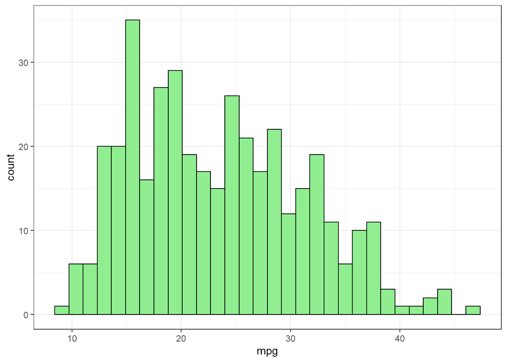

```r
ggplot(Auto,aes(x=mpg))+geom_histogram(fill="lightgreen",colour="black",bins=30)+theme_bw()
```

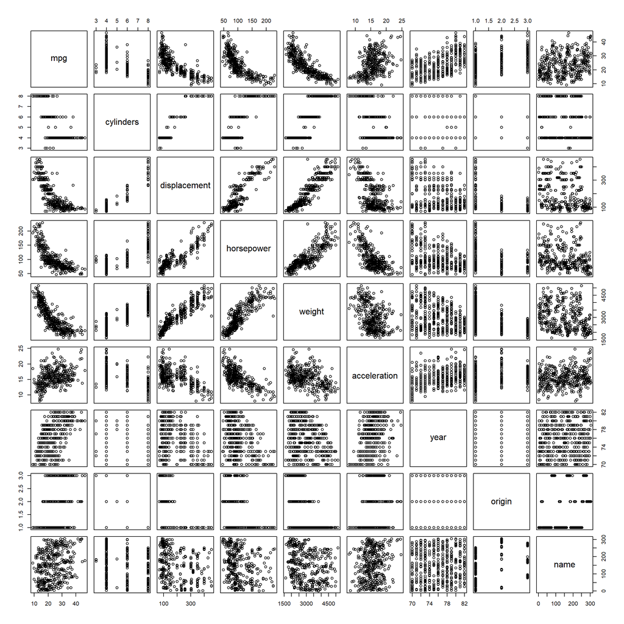

```r
pairs(Auto)
```

```r
library(GGally)
```

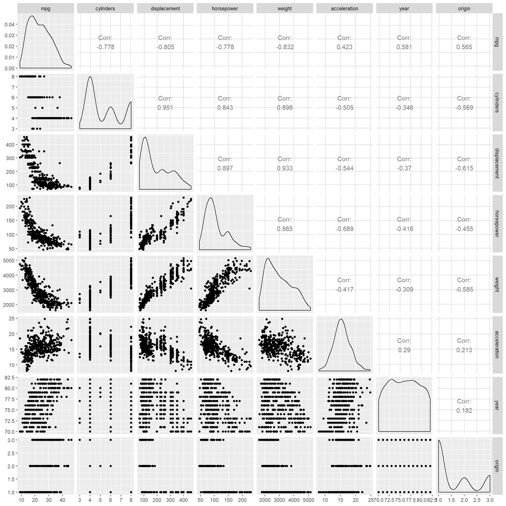

```r
ggpairs(Auto[,-ncol(Auto)])
```

```r
summary(Auto)
```

```
##       mpg          cylinders      displacement     horsepower
##  Min.   : 9.00   Min.   :3.000   Min.   : 68.0   Min.   : 46.0
##  1st Qu.:17.00   1st Qu.:4.000   1st Qu.:105.0   1st Qu.: 75.0
##  Median :22.75   Median :4.000   Median :151.0   Median : 93.5
##  Mean   :23.45   Mean   :5.472   Mean   :194.4   Mean   :104.5
##  3rd Qu.:29.00   3rd Qu.:8.000   3rd Qu.:275.8   3rd Qu.:126.0
##  Max.   :46.60   Max.   :8.000   Max.   :455.0   Max.   :230.0
##
##      weight      acceleration        year           origin
##  Min.   :1613   Min.   : 8.00   Min.   :70.00   Min.   :1.000
##  1st Qu.:2225   1st Qu.:13.78   1st Qu.:73.00   1st Qu.:1.000
##  Median :2804   Median :15.50   Median :76.00   Median :1.000
##  Mean   :2978   Mean   :15.54   Mean   :75.98   Mean   :1.577
##  3rd Qu.:3615   3rd Qu.:17.02   3rd Qu.:79.00   3rd Qu.:2.000
##  Max.   :5140   Max.   :24.80   Max.   :82.00   Max.   :3.000
##
##                  name
##  amc matador       :  5
##  ford pinto        :  5
##  toyota corolla    :  5
##  amc gremlin       :  4
##  amc hornet        :  4
##  chevrolet chevette:  4
##  (Other)           :365
```

```r
summary(Auto$mpg)
```

```
##    Min. 1st Qu.  Median    Mean 3rd Qu.    Max.
##    9.00   17.00   22.75   23.45   29.00   46.60
```

# ISRL Ch.2.4 (Exercises – applied)

## Problem 8 (a-b)

About reading data from the file and viewing it using `fix` data editor function

## Problem 8 (c)

*i. Use the `summary()` function to produce a numerical summary of the variables in the data set.*

```r
summary(College)
```

```
##  Private        Apps           Accept          Enroll       Top10perc
##  No :212   Min.   :   81   Min.   :   72   Min.   :  35   Min.   : 1.00
##  Yes:565   1st Qu.:  776   1st Qu.:  604   1st Qu.: 242   1st Qu.:15.00
##            Median : 1558   Median : 1110   Median : 434   Median :23.00
##            Mean   : 3002   Mean   : 2019   Mean   : 780   Mean   :27.56
##            3rd Qu.: 3624   3rd Qu.: 2424   3rd Qu.: 902   3rd Qu.:35.00
##            Max.   :48094   Max.   :26330   Max.   :6392   Max.   :96.00
##    Top25perc      F.Undergrad     P.Undergrad         Outstate
##  Min.   :  9.0   Min.   :  139   Min.   :    1.0   Min.   : 2340
##  1st Qu.: 41.0   1st Qu.:  992   1st Qu.:   95.0   1st Qu.: 7320
##  Median : 54.0   Median : 1707   Median :  353.0   Median : 9990
##  Mean   : 55.8   Mean   : 3700   Mean   :  855.3   Mean   :10441
##  3rd Qu.: 69.0   3rd Qu.: 4005   3rd Qu.:  967.0   3rd Qu.:12925
##  Max.   :100.0   Max.   :31643   Max.   :21836.0   Max.   :21700
##    Room.Board       Books           Personal         PhD
##  Min.   :1780   Min.   :  96.0   Min.   : 250   Min.   :  8.00
##  1st Qu.:3597   1st Qu.: 470.0   1st Qu.: 850   1st Qu.: 62.00
##  Median :4200   Median : 500.0   Median :1200   Median : 75.00
##  Mean   :4358   Mean   : 549.4   Mean   :1341   Mean   : 72.66
##  3rd Qu.:5050   3rd Qu.: 600.0   3rd Qu.:1700   3rd Qu.: 85.00
##  Max.   :8124   Max.   :2340.0   Max.   :6800   Max.   :103.00
##     Terminal       S.F.Ratio      perc.alumni        Expend
##  Min.   : 24.0   Min.   : 2.50   Min.   : 0.00   Min.   : 3186
##  1st Qu.: 71.0   1st Qu.:11.50   1st Qu.:13.00   1st Qu.: 6751
##  Median : 82.0   Median :13.60   Median :21.00   Median : 8377
##  Mean   : 79.7   Mean   :14.09   Mean   :22.74   Mean   : 9660
##  3rd Qu.: 92.0   3rd Qu.:16.50   3rd Qu.:31.00   3rd Qu.:10830
##  Max.   :100.0   Max.   :39.80   Max.   :64.00   Max.   :56233
##    Grad.Rate
##  Min.   : 10.00
##  1st Qu.: 53.00
##  Median : 65.00
##  Mean   : 65.46
##  3rd Qu.: 78.00
##  Max.   :118.00
```

```r
head(College)
```

```
##                              Private Apps Accept Enroll Top10perc
## Abilene Christian University     Yes 1660   1232    721        23
## Adelphi University               Yes 2186   1924    512        16
## Adrian College                   Yes 1428   1097    336        22
## Agnes Scott College              Yes  417    349    137        60
## Alaska Pacific University        Yes  193    146     55        16
## Albertson College                Yes  587    479    158        38
##                              Top25perc F.Undergrad P.Undergrad Outstate
## Abilene Christian University        52        2885         537     7440
## Adelphi University                  29        2683        1227    12280
## Adrian College                      50        1036          99    11250
## Agnes Scott College                 89         510          63    12960
## Alaska Pacific University           44         249         869     7560
## Albertson College                   62         678          41    13500
##                              Room.Board Books Personal PhD Terminal
## Abilene Christian University       3300   450     2200  70       78
## Adelphi University                 6450   750     1500  29       30
## Adrian College                     3750   400     1165  53       66
## Agnes Scott College                5450   450      875  92       97
## Alaska Pacific University          4120   800     1500  76       72
## Albertson College                  3335   500      675  67       73
##                              S.F.Ratio perc.alumni Expend Grad.Rate
## Abilene Christian University      18.1          12   7041        60
## Adelphi University                12.2          16  10527        56
## Adrian College                    12.9          30   8735        54
## Agnes Scott College                7.7          37  19016        59
## Alaska Pacific University         11.9           2  10922        15
## Albertson College                  9.4          11   9727        55
```

*ii. Use the `pairs()` function to produce a scatterplot matrix of the first ten columns or variables of the data. Recall that you can reference the first ten columns of a matrix `A` using `A[,1:10]`.*

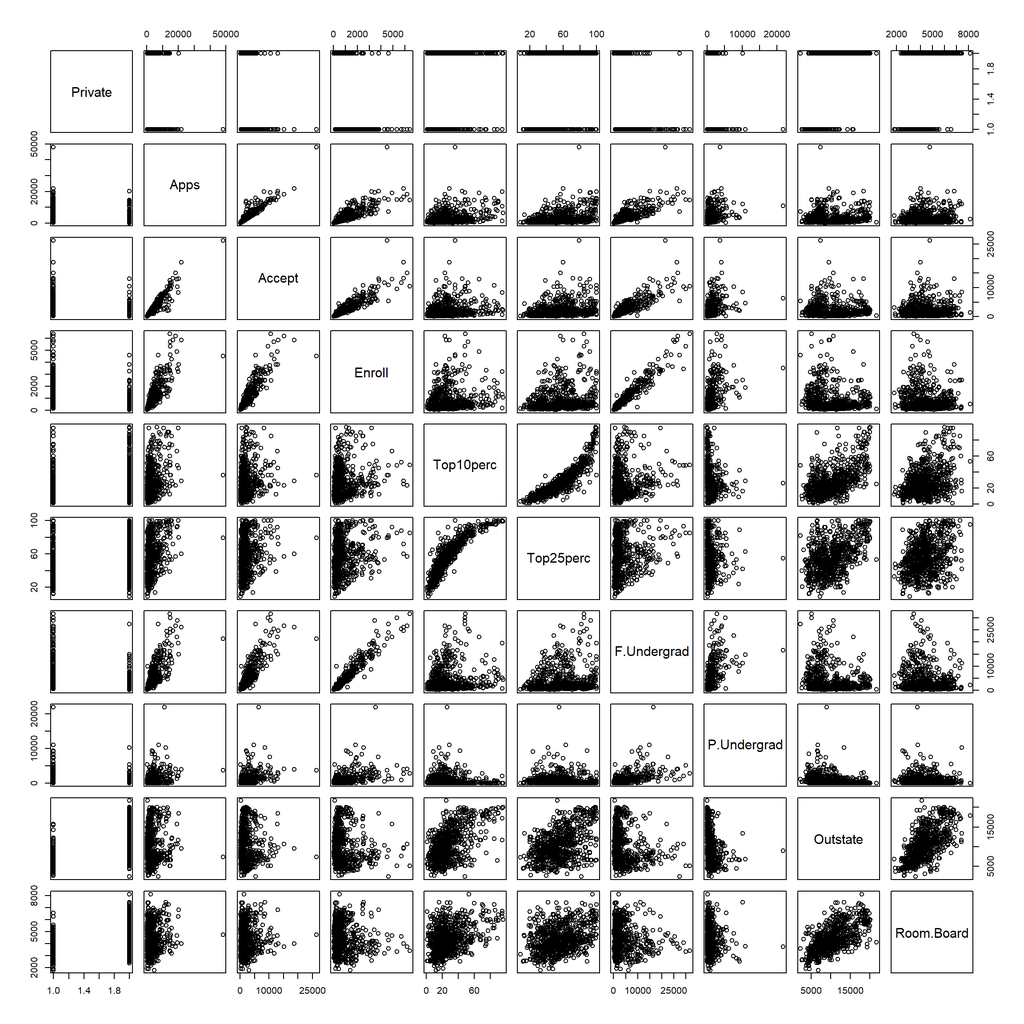

```r
pairs(College[,1:10])
```

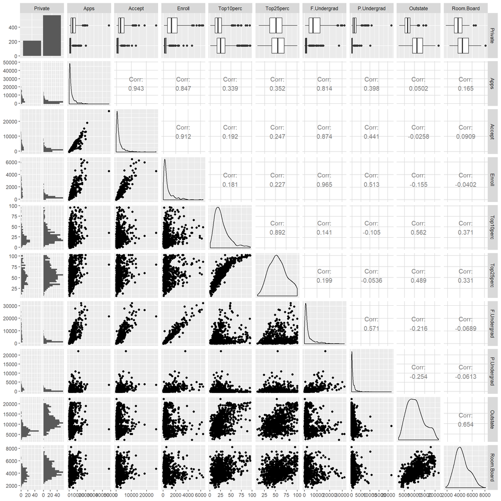

```r
ggpairs(College[,1:10])
```

*iii. Use the `plot()` function to produce side-by-side boxplots of `Outstate` versus `Private`.*

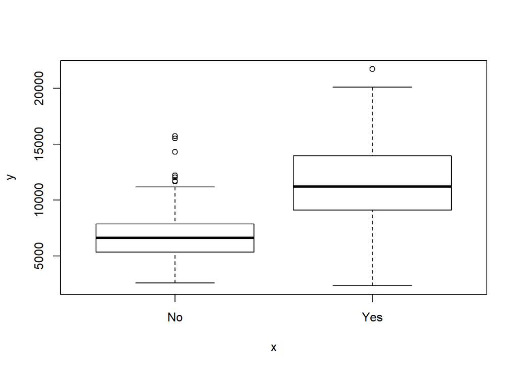

```r
plot(College$Private,College$Outstate)
```

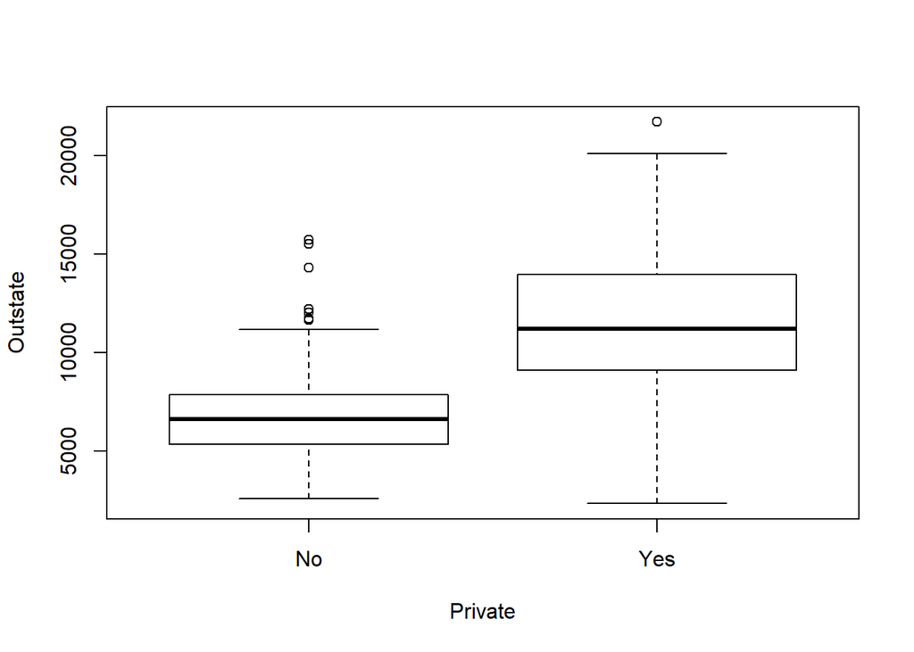

```r
boxplot(Outstate~Private,College)
```

```r
class(College$Private)
```

```
## [1] "factor"
```

```r
table(College$Private)
```

```
##
##  No Yes
## 212 565
```

```r
class(College$Outstate)
```

```
## [1] "numeric"
```

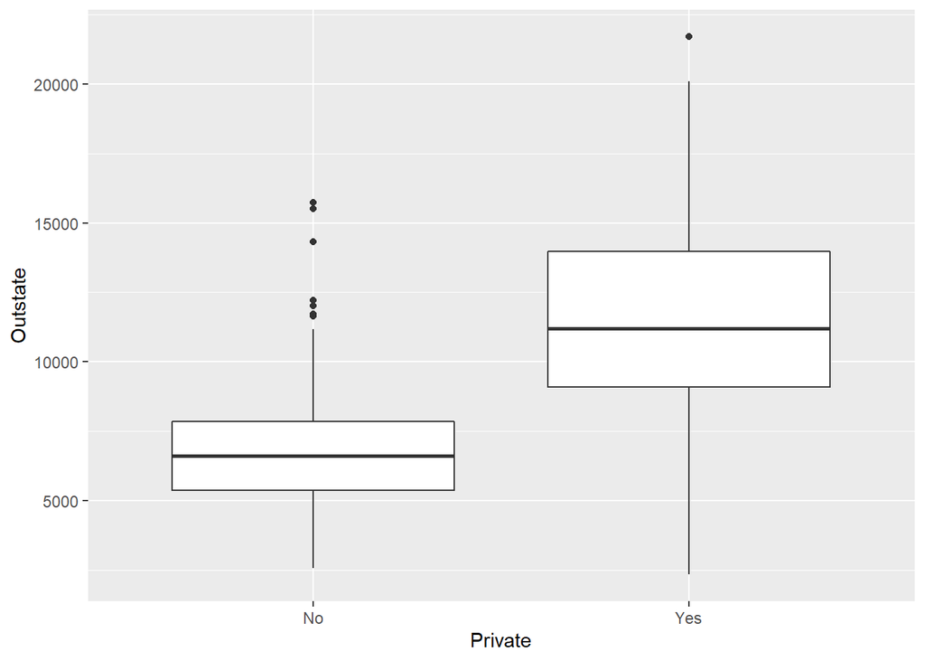

```r
ggplot(College,aes(x=Private,y=Outstate)) + geom_boxplot()
```

*iv. Create a new qualitative variable, called `Elite`, by binning the `Top10perc` variable. We are going to divide universities into two groups based on whether or not the proportion of students coming from the top 10% of their high school classes exceeds 50%.*

*Use the `summary()` function to see how many elite universities there are. Now use the `plot()` function to produce side-by-side boxplots of `Outstate` versus `Elite`.*

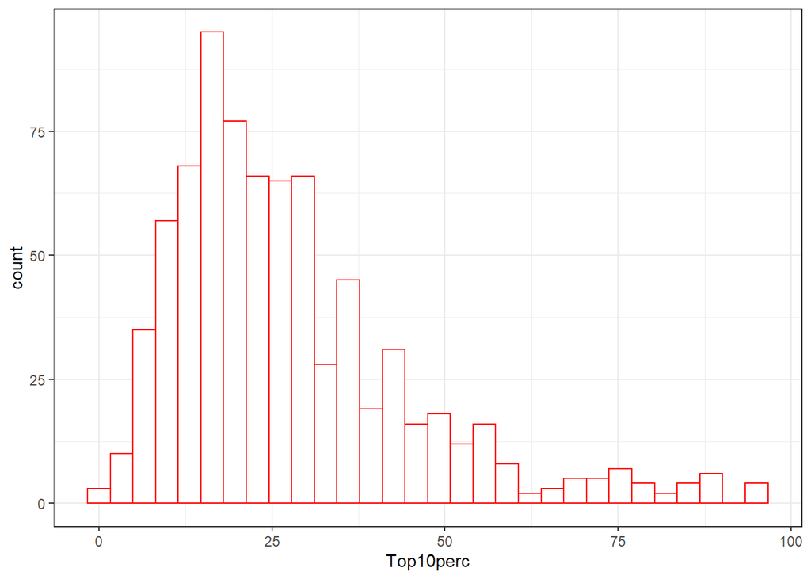

```r
ggplot(College,aes(x=Top10perc))+geom_histogram(colour="red",fill="white")+theme_bw()
```

```r
# another way to accomplish what is shown in the textbook:
College$Elite <- factor(c("No","Yes")[as.numeric(College$Top10perc>50)+1])
summary(College$Elite)
```

```
##  No Yes
## 699  78
```

```r
table(College$Elite)
```

```
##
##  No Yes
## 699  78
```

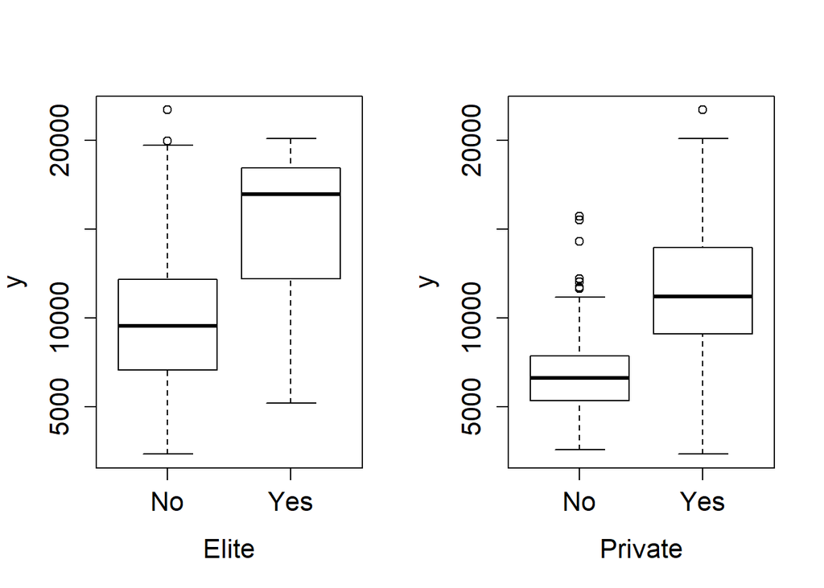

```r
old.par <- par(mfrow=c(1,2),ps=16)
plot(College$Elite,College$Outstate,xlab="Elite")
plot(College$Private,College$Outstate,xlab="Private")
```

```r
par(old.par)
head(melt(College[,c("Elite","Private","Outstate")]))
```

```
##   Elite Private variable value
## 1    No     Yes Outstate  7440
## 2    No     Yes Outstate 12280
## 3    No     Yes Outstate 11250
## 4   Yes     Yes Outstate 12960
## 5    No     Yes Outstate  7560
## 6    No     Yes Outstate 13500
```

```r
head(melt(College[,c("Elite","Private","Outstate")],id="Outstate"))
```

```
##   Outstate variable value
## 1     7440    Elite    No
## 2    12280    Elite    No
## 3    11250    Elite    No
## 4    12960    Elite   Yes
## 5     7560    Elite    No
## 6    13500    Elite    No
```

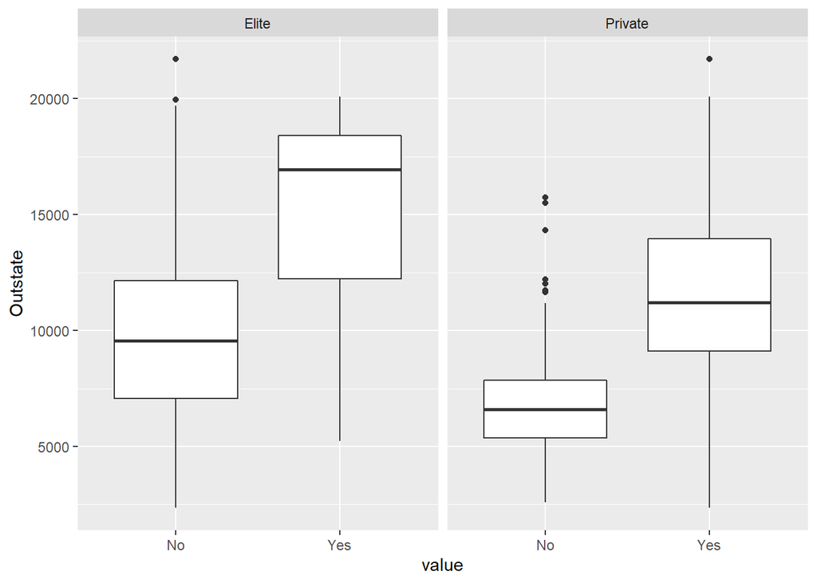

```r
ggplot(melt(College[,c("Elite","Private","Outstate")],id="Outstate"),aes(x=value,y=Outstate))+geom_boxplot()+facet_wrap(~variable)
```

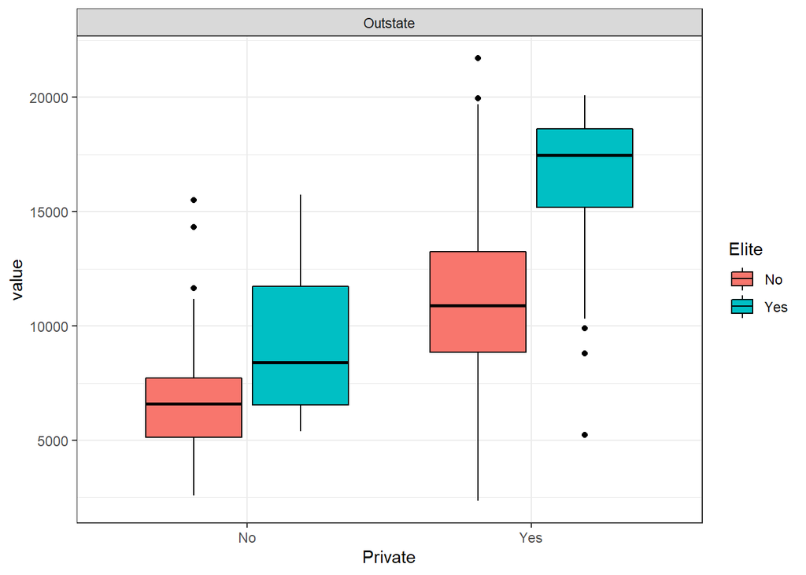

```r
ggplot(melt(College[,c("Elite","Private","Outstate")]),aes(x=Private,y=value,fill=Elite,colour=Elite))+geom_boxplot(colour="black")+facet_wrap(~variable)+theme_bw()
```

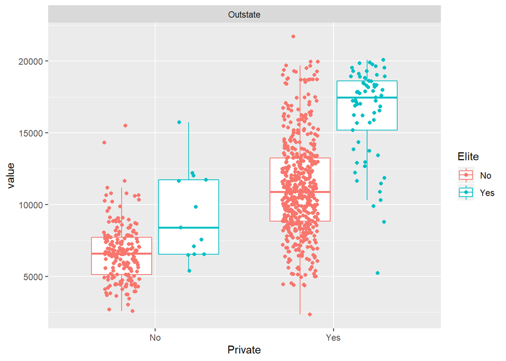

```r
ggplot(melt(College[,c("Elite","Private","Outstate")]),aes(x=Private,y=value,fill=Elite,colour=Elite))+geom_boxplot(fill="white",outlier.colour=NA)+geom_point(position=position_jitterdodge())+facet_wrap(~variable)
```

```r
table(College[,c("Elite","Private")])
```

```
##      Private
## Elite  No Yes
##   No  199 500
##   Yes  13  65
```

```r
fisher.test(table(College[,c("Elite","Private")]))
```

```
##
##  Fisher's Exact Test for Count Data
##
## data:  table(College[, c("Elite", "Private")])
## p-value = 0.03125
## alternative hypothesis: true odds ratio is not equal to 1
## 95 percent confidence interval:
##  1.056005 4.023294
## sample estimates:
## odds ratio
##   1.988466
```

```r
chisq.test(table(College[,c("Elite","Private")]))
```

```
##
##  Pearson's Chi-squared test with Yates' continuity correction
##
## data:  table(College[, c("Elite", "Private")])
## X-squared = 4.3498, df = 1, p-value = 0.03701
```

```r
summary(lm(Outstate~Private*Elite,College))
```

```
##
## Call:
## lm(formula = Outstate ~ Private * Elite, data = College)
##
## Residuals:
##      Min       1Q   Median       3Q      Max
## -11209.5  -2069.6    -99.4   1750.6  10500.4
##
## Coefficients:
##                     Estimate Std. Error t value Pr(>|t|)
## (Intercept)           6649.4      214.2  31.037  < 2e-16 ***
## PrivateYes            4550.1      253.3  17.963  < 2e-16 ***
## EliteYes              2674.4      865.2   3.091  0.00207 **
## PrivateYes:EliteYes   2559.6      952.5   2.687  0.00736 **
## ---
## Signif. codes:  0 '***' 0.001 '**' 0.01 '*' 0.05 '.' 0.1 ' ' 1
##
## Residual standard error: 3022 on 773 degrees of freedom
## Multiple R-squared:  0.4378, Adjusted R-squared:  0.4357
## F-statistic: 200.7 on 3 and 773 DF,  p-value: < 2.2e-16
```

## Problem 9

**This exercise involves the `Auto` data set studied in the lab. Make sure that the missing values have been removed from the data.**

### Problem 9 (a)

*Which of the predictors are quantitative, and which are qualitative?*

```r
head(Auto)
```

```
##   mpg cylinders displacement horsepower weight acceleration year origin
## 1  18         8          307        130   3504         12.0   70      1
## 2  15         8          350        165   3693         11.5   70      1
## 3  18         8          318        150   3436         11.0   70      1
## 4  16         8          304        150   3433         12.0   70      1
## 5  17         8          302        140   3449         10.5   70      1
## 6  15         8          429        198   4341         10.0   70      1
##                        name
## 1 chevrolet chevelle malibu
## 2         buick skylark 320
## 3        plymouth satellite
## 4             amc rebel sst
## 5               ford torino
## 6          ford galaxie 500
```

```r
summary(Auto)
```

```
##       mpg          cylinders      displacement     horsepower
##  Min.   : 9.00   Min.   :3.000   Min.   : 68.0   Min.   : 46.0
##  1st Qu.:17.00   1st Qu.:4.000   1st Qu.:105.0   1st Qu.: 75.0
##  Median :22.75   Median :4.000   Median :151.0   Median : 93.5
##  Mean   :23.45   Mean   :5.472   Mean   :194.4   Mean   :104.5
##  3rd Qu.:29.00   3rd Qu.:8.000   3rd Qu.:275.8   3rd Qu.:126.0
##  Max.   :46.60   Max.   :8.000   Max.   :455.0   Max.   :230.0
##
##      weight      acceleration        year           origin
##  Min.   :1613   Min.   : 8.00   Min.   :70.00   Min.   :1.000
##  1st Qu.:2225   1st Qu.:13.78   1st Qu.:73.00   1st Qu.:1.000
##  Median :2804   Median :15.50   Median :76.00   Median :1.000
##  Mean   :2978   Mean   :15.54   Mean   :75.98   Mean   :1.577
##  3rd Qu.:3615   3rd Qu.:17.02   3rd Qu.:79.00   3rd Qu.:2.000
##  Max.   :5140   Max.   :24.80   Max.   :82.00   Max.   :3.000
##
##                  name
##  amc matador       :  5
##  ford pinto        :  5
##  toyota corolla    :  5
##  amc gremlin       :  4
##  amc hornet        :  4
##  chevrolet chevette:  4
##  (Other)           :365
```

### Problem 9 (b)

*What is the range of each quantitative predictor? You can answer this using the `range()` function.*

```r
apply(Auto[,1:7],2,range)
```

```
##       mpg cylinders displacement horsepower weight acceleration year
## [1,]  9.0         3           68         46   1613          8.0   70
## [2,] 46.6         8          455        230   5140         24.8   82
```

### Problem 9 (c)

*What is the mean and standard deviation of each quantitative predictor?*

```r
apply(Auto[,1:7],2,mean)
```

```
##          mpg    cylinders displacement   horsepower       weight
##    23.445918     5.471939   194.411990   104.469388  2977.584184
## acceleration         year
##    15.541327    75.979592
```

```r
apply(Auto[,1:7],2,median)
```

```
##          mpg    cylinders displacement   horsepower       weight
##        22.75         4.00       151.00        93.50      2803.50
## acceleration         year
##        15.50        76.00
```

```r
apply(Auto[,1:7],2,sd)
```

```
##          mpg    cylinders displacement   horsepower       weight
##     7.805007     1.705783   104.644004    38.491160   849.402560
## acceleration         year
##     2.758864     3.683737
```

```r
apply(Auto[,1:7],2,mad)
```

```
##          mpg    cylinders displacement   horsepower       weight
##      8.59908      0.00000     90.43860     28.91070    948.12270
## acceleration         year
##      2.52042      4.44780
```

```r
if ( FALSE ) {
  # returns NA's for every column - why?
  apply(Auto,2,mean)
}
```

### Problem 9 (d)

*Now remove the 10th through 85th observations. What is the range, mean, and standard deviation of each predictor in the subset of the data that remains?*

```r
apply(Auto[-(10:85),1:7],2,range)
```

```
##       mpg cylinders displacement horsepower weight acceleration year
## [1,] 11.0         3           68         46   1649          8.5   70
## [2,] 46.6         8          455        230   4997         24.8   82
```

```r
apply(Auto[-(10:85),1:7],2,mean)
```

```
##          mpg    cylinders displacement   horsepower       weight
##    24.404430     5.373418   187.240506   100.721519  2935.971519
## acceleration         year
##    15.726899    77.145570
```

```r
apply(Auto[-(10:85),1:7],2,sd)
```

```
##          mpg    cylinders displacement   horsepower       weight
##     7.867283     1.654179    99.678367    35.708853   811.300208
## acceleration         year
##     2.693721     3.106217
```

### Problem 9 (e)

*Using the full data set, investigate the predictors graphically, using scatterplots or other tools of your choice. Create some plots highlighting the relationships among the predictors. Comment on your findings.*

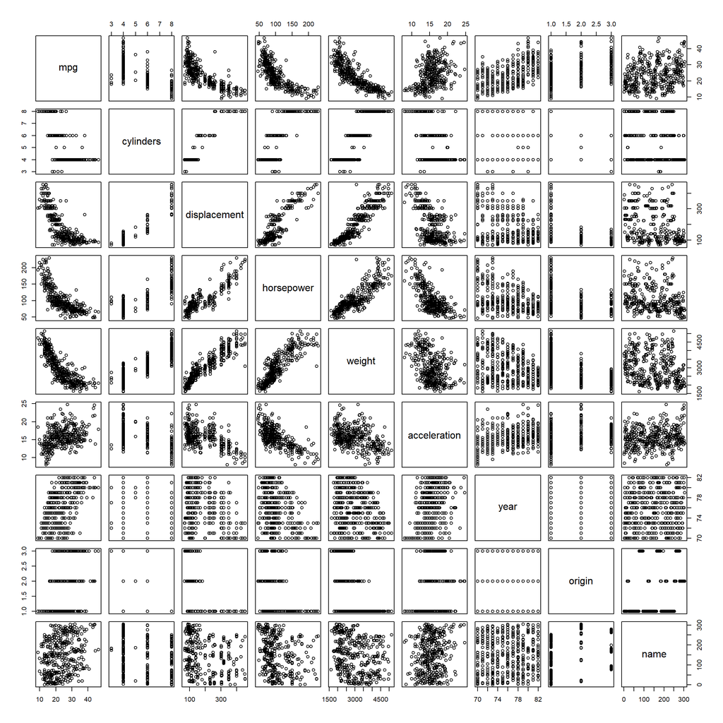

```r
pairs(Auto)
```

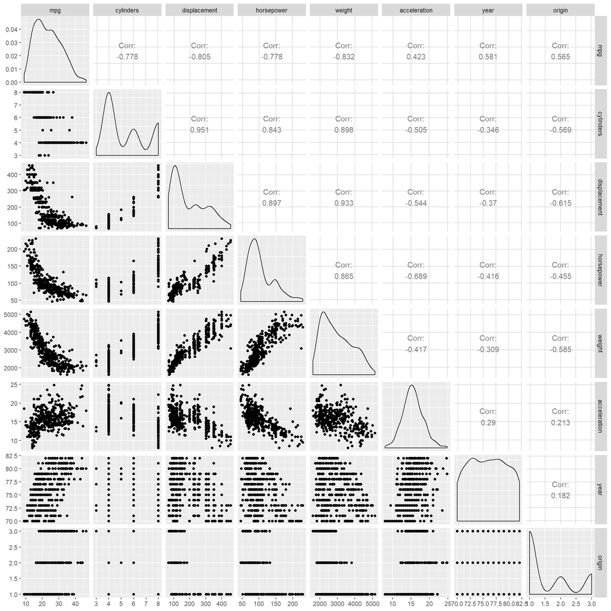

```r
ggpairs(Auto[,-ncol(Auto)])
```

### Problem 9 (f)

*Suppose that we wish to predict gas mileage (`mpg`) on the basis of the other variables. Do your plots suggest that any of the other variables might be useful in predicting `mpg`? Justify your answer.*